# Approximating the Posterior

## Autocorrelation

- Autocorrelation allows us to evaluate if our Markov chain sufficiently mimics the behavior of an independent sample.
- **Autocorrelation**:
  - *Lag 1* autocorrelation measures the correlation between pairs of Markov chain values that are one “step” apart (e.g., $\pi_i$ and $\pi_{(i-1)}$; e.g., $\pi_4$ and $\pi_3$).
  - *Lag 2* autocorrelation measures the correlation between pairs of Markov chain values that are two “steps apart (e.g., $\pi_i$ and $\pi_{(i-2)}$; e.g., $\pi_4$ and $\pi_2$).
  - *Lag $k$* autocorrelation measures the correlation between pairs of Markov chain values that are $k$ “steps” apart (e.g., $\pi_i$ and $\pi_{(i-k)}$; e.g., $\pi_4$ and $\pi_{(4-k)}$).

## Autocorrelation

- Autocorrelation allows us to evaluate if our Markov chain sufficiently mimics the behavior of an independent sample.
- Strong autocorrelation or dependence is a bad thing.
  - It goes hand in hand with small effective sample size ratios.
  - These provide a warning sign that our resulting posterior approximations might be unreliable.

## Autocorrelation

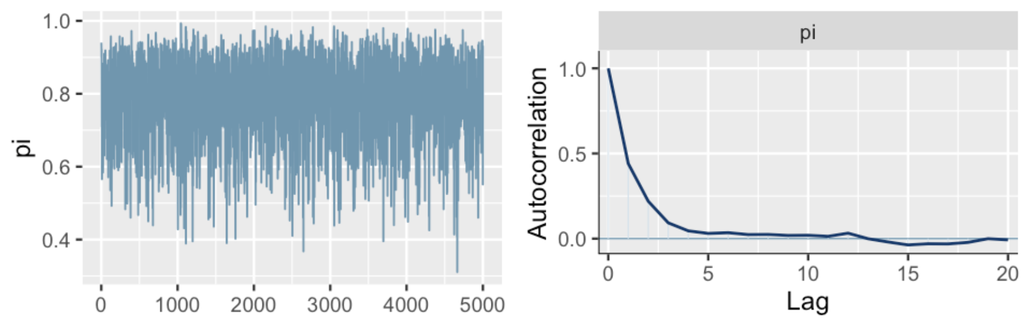

- No obvious patterns in the trace plot; dependence is relatively weak.
- Autocorrelation plot quickly drops off and is effectively 0 by lag 5.
- Confirmation that our Markov chain is mixing quickly.
  - i.e., quickly moving around the range of posterior plausible $\pi$ values
  - i.e., at least mimicking an independent sample.

## Autocorrelation

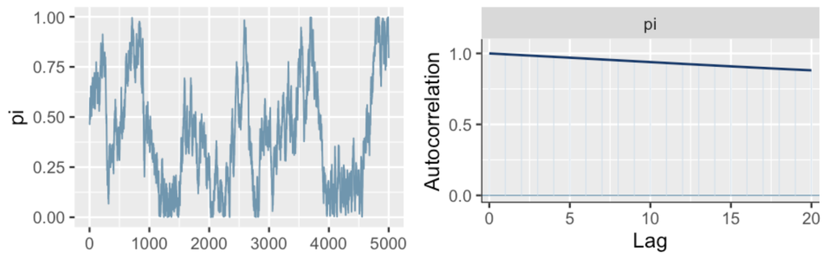

- This is an “unhealthy” Markov chain.
- Trace plot shows strong trends $\to$ autocorrelation in the Markov chain values.
- Slow decrease in autocorrelation plot indicates that the dependence between chain values does not quickly fade away.
  - At lag 20, the autocorrelation is still $\sim$ 90%.

## Fast vs. Slow Mixing Markov Chains

- **Fast mixing** chains:
  - The chains move “quickly” around the range of posterior plausible values
  - The autocorrelation among the chain values drops off quickly.
  - The effective sample size ratio is reasonably large.
- **Slow mixing** chains:
  - The chains move “slowly” around the range of posterior plauslbe values.
  - The autocorrelation among the chainv alues drops off very slowly.
  - The effective sample size ratio is small.
- What do we do if we have a slow mixing chain?
  - Increase the chain size :)
  - Thin the Markov chain :|

## $\hat{R}$

$$\hat{R} \approx \sqrt{\frac{\text{var}_{\text{combined}}}{\text{var}_{\text{within}}}}$$

- where
  - $\text{var}_{\text{combined}}$ is the variability in $\theta$ across all chains combined.
  - $\text{var}_{\text{within}}$ is the typical variability within any individual chain.
- $\hat{R}$ compares the variability in sampled $\theta$ values across all chains combined with the variability within each individual change.
  - Ideally, $\hat{R} \approx 1$, showing stability across chains.
  - $\hat{R} > 1$ indicates instability with the variability in the combined chains larger than that of the variability within the chains.
  - $\hat{R} > 1.05$ raises red flags about the stability of the simulation.

## $\hat{R}$

- We can use the `rhat()` function from the `bayesplot` package to find $\hat{R}$.

```r
rhat(bb_sim, pars = "pi")
```

```
[1] 1.000245
```

- We can see that our simulation is stable.
- If we were to find $\hat{R}$ for the other (obviously bad) simulation, it would be 5.35 😱